# Dimension reduction analysis on Australian Football League

Jason Ching Yuen, Siu

### Data description

Principal component analysis is often used to create indicator variables. In this question, you will look at the womens AFL data provided in the [fitzRoy package](https://jimmyday12.github.io/fitzRoy/) to create an indicator variable for offensive skills, using PCA.

Download the 2020 season player stats. Compute the average of the statistics for each player. (There are two players who have two different names - this can happen when a women gets married, but it can also happen as a data entry mistake. Make sure these duplicates are removed.)

### Data preprocessing

**Two things are performed before analysis.** **Firstly, we found that two players who have two different names, whose IDs are “CD_I1011127” and “CD_I1011127”. So, we changed their names to their original names to make it more consistent. Secondly, we also compute the mean because different players have different number of matches.**

### Compute the total variance

**Assuming standardised variables, the total variance is 34, which is the number of variables.**

### Compute a proportion of variance

**The proportion of variance that can be explained by the first two PCs are 50.204116%.**

### PCA interpretion

Examine the loadings for the PC1 and PC2. Make plots of the loadings.

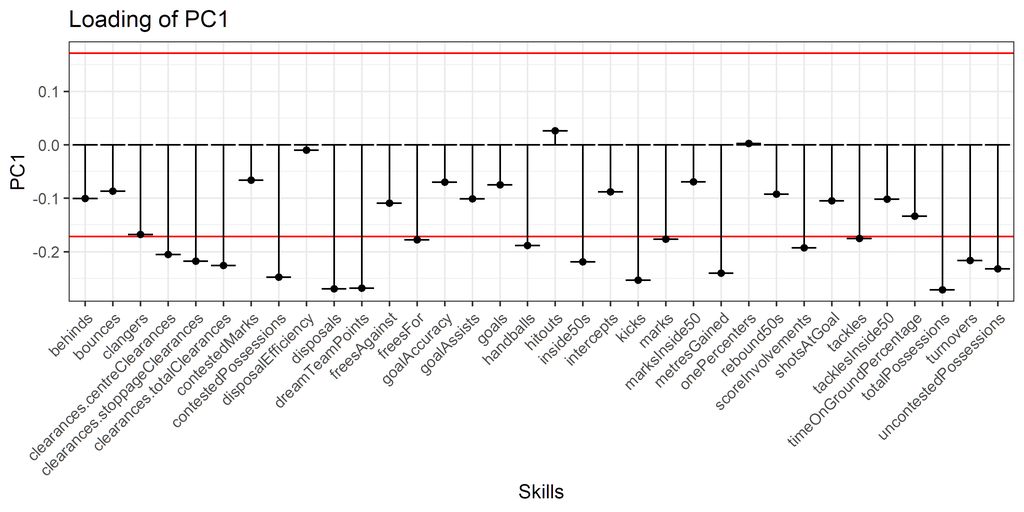

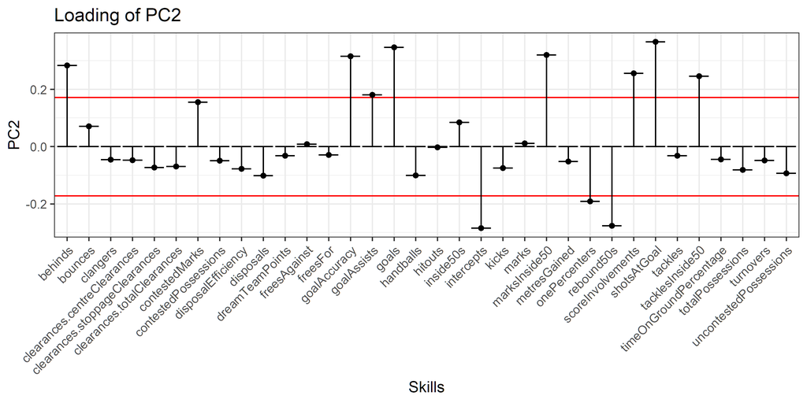

### PC2 might be used as an indicator for offensive player skills.

**Because variables which went beyond the line of critical values (those which are statistically significant) are mostly offensive-related, particularly for goals**

### Bootstrap confidence interval

Use bootstrap to assess which variables could be considered unimportant for PC2 (ie loadings not significantly different from 0).

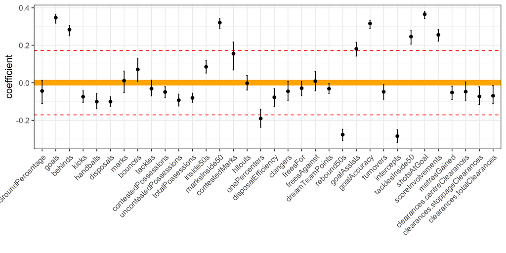

### Math equation

Write down the formula for your new indicator variable. Explain your reasoning (in 30 words or less).

**The formula for new indicator variable is written as**
$$\phi_{1} \times goals + \phi_{2} \times behinds + \phi_{3} \times marksinside50 + \phi_{4} \times contestedMarks + \phi_{5} \times onePercenters + \phi_{6} \times rebound50s
\\ + \phi_{7} \times goalAssists + \phi_{8} \times goalAccuracy + \phi_{9} \times intercepts + \phi_{10} \times tacklesInside50 + \phi_{11} \times shotAtGoal + \phi_{12} \times scoreInvolcements.$$

### PCA plot

Make a biplot of the first two PCs. Which few players have the highest values, and which few players have the lowest value on PC2? What does it mean for a player to have a high value on PC2?

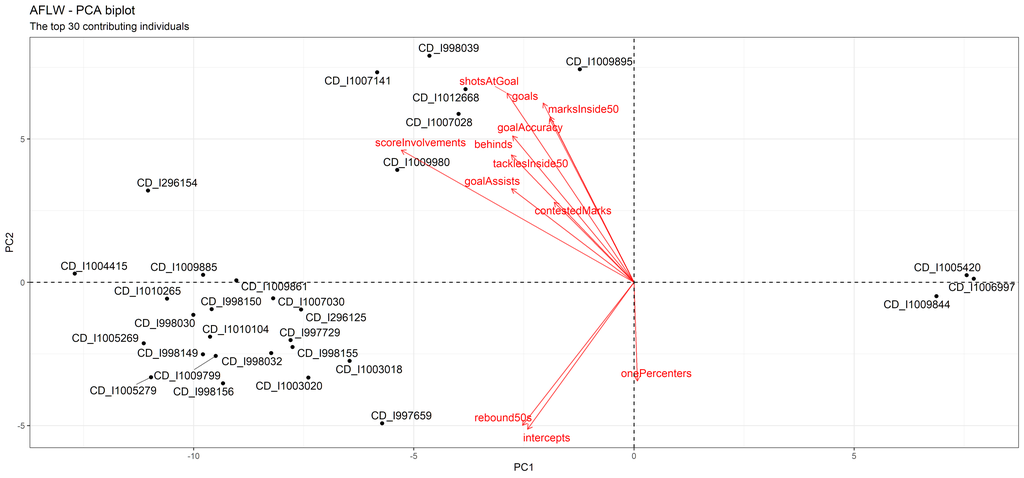

**This plot projects the top 30 players.**

**On PC2, Player CD_l998039, CD_l007141 and CD_l1009895 are dubbed as the top 3 players whereas CD_l997659, CD_l998156 and CD_l1003020 have the three lowest value.**

**Those top 3 players on PC2 tends to have higher goal-related (e.g., goal accuracy) and score-related variables, so we can interpret that they are great at offensive skills, such as having high goal accuracy, assisting teammates to goal, and higher score involvement.**